# Sentiment analysis of a restaurant

This is a part 1 of sentitment analysis of review for a restaurant. We will analyse the reviews using various options like word frequency, wordcloud, text and sentiment analytics.

What is their current rating summary?

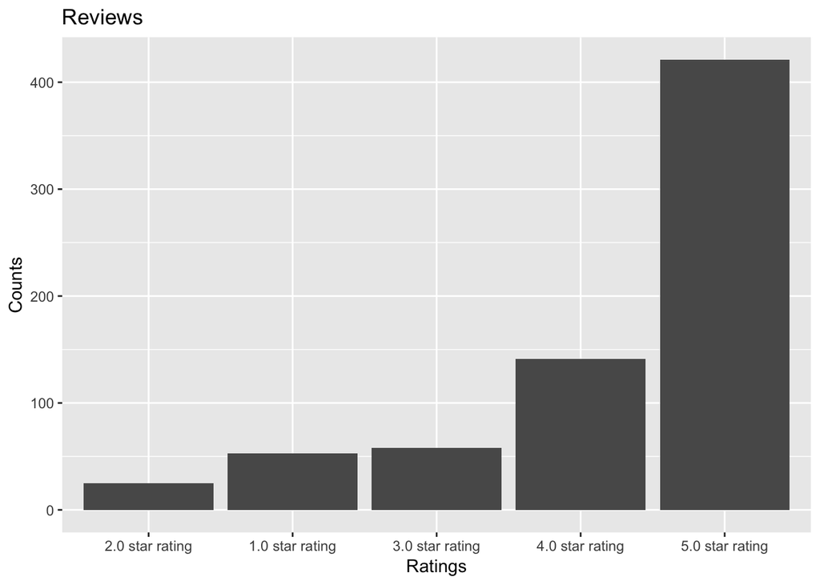

**Comments** They are surely 5 star rated by the community and surely deserves your visit when hungry.

Lets review overall ratings on Year & Month

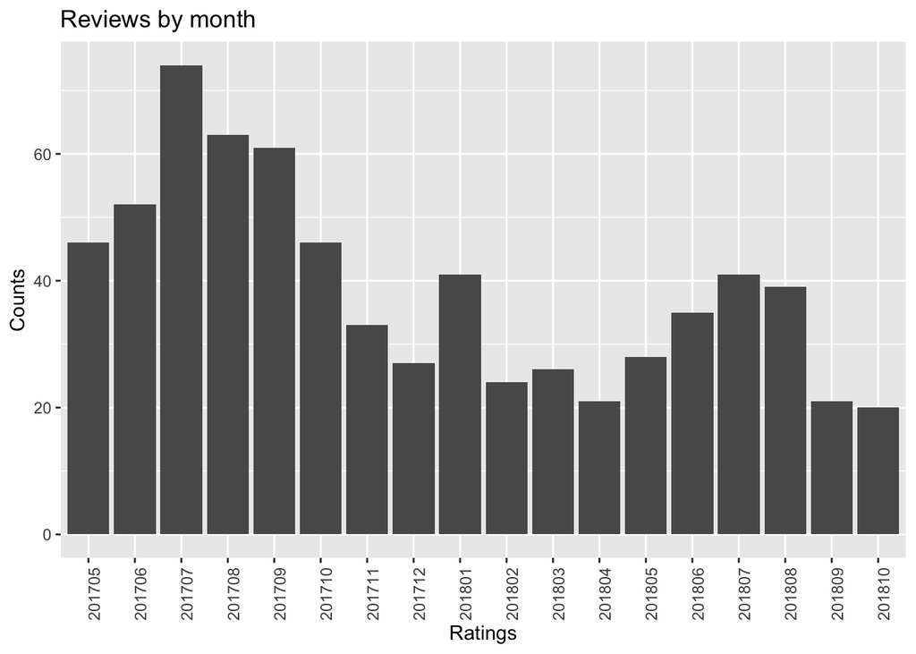

**Comments** Something happened in Feb,Mar of 2018 with the dip in overall ratings. Overall the ratings are dipping as compared with 2017.

Lets facet on Weekday

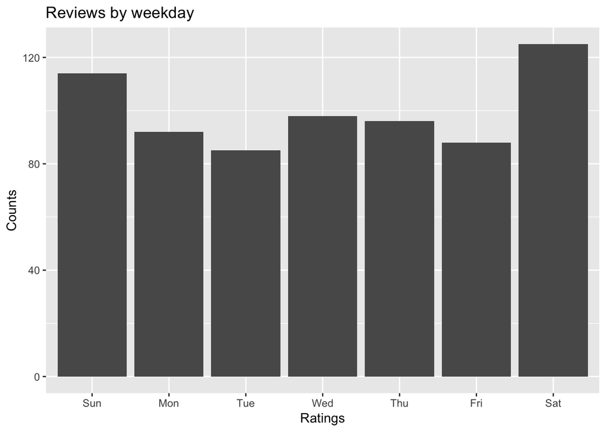

**Comments** Weekends seems to be the most frequent time for eating out and reviews.

Lets review overall ratings on Year & Month by the category of ratings Low:High

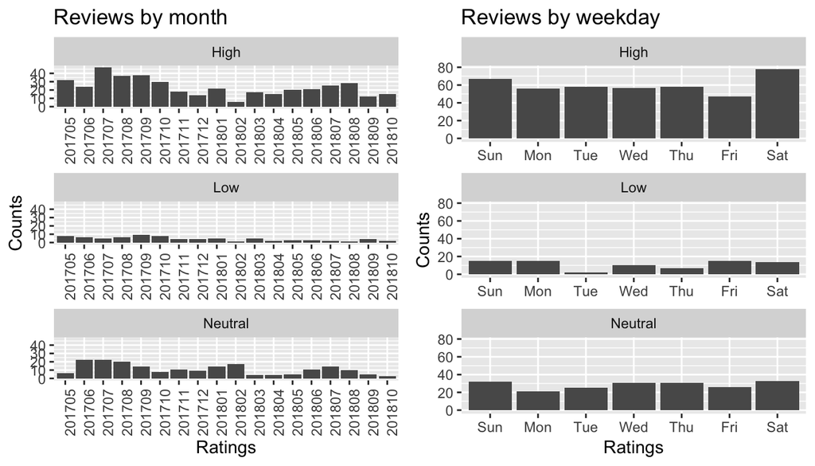

**Comments** 201802 Feb has a dip in the high ratings and a spike in the neutral at same time. Low ratings have been consistent with spikes in 201709-10. Low ratings tend to be least on Tuesday.

Now lets view the types of reviewers who are giving their reviews/ratings, who are they and where are they from?

First, lets see where our reviewers come from

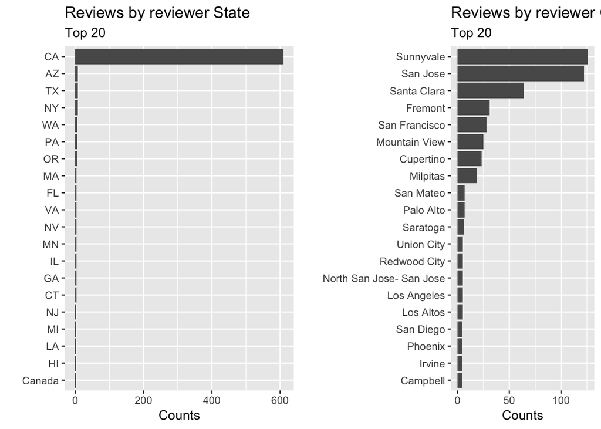

**Comments** Hands down CALIFORNIA responses !. Its a local crowd that eats and reviews. Good to see folks from Arizona and Texas are showing up as well!

Understandably the very local crowd are eating here and responding the goods/bads.And.. we had someone come all the way from San Diego to eat here !

With the reviewer locations out of the way lets see the reviewers overall volume of reviews. We can then do more analysis based on the folks who have high volume of reviews as compared with the low volume.

High volume of reviews mean the folks are most busy visiting places(truthfully !) and providing their reviews. We do hear about people providing paid services for reviews so hoping this is not the case.

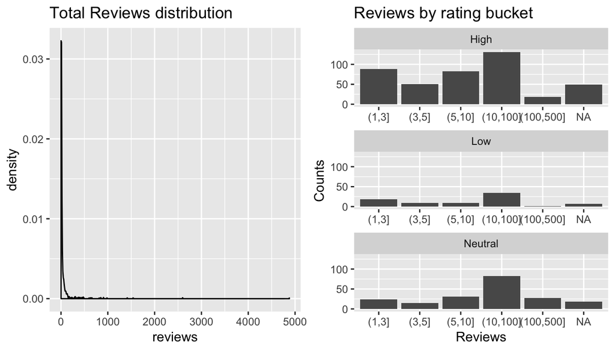

**Comments** Most of the reviewers are within the 0-10 reviews so likely honest users providing their reviews as they happen. We also have folks with 3000+ reviews as well and these could be genuine or paid review providers. So reviewers with x0-100 reviews are the most frequent and they span across all 3 categories. The NA are the very high reviews users.

Low ratings from [1-3] are likely the trigger happy folks who did not like something and shot off the review.

Now lets do some word frequency for all reviews and see which words stand out.

[interactive chart not shown]

**Comments** Other than the obvious keywords we see that Chicken dishes , lassi, biryani have high reviews. There are reviews on price, spice, staff etc and we will deep dive into them later to confirm if the reviews are good/bad.

Lets plot the words based on the High/Neutral/Low ratings and see what words are common.

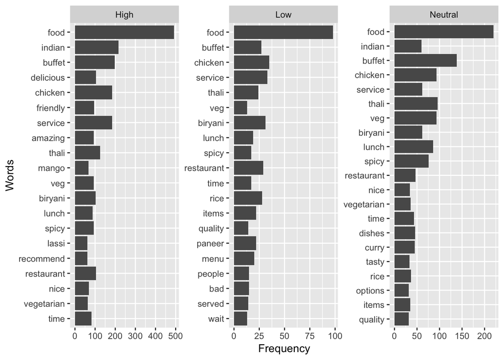

**Comments** Mango and lassi have some high reviews along with their Thali, buffet BUT the majority low ratings are also on “food”, “biryani”.

We also have to accomodate for a combination of happy/unhappy statements within single review. Ex: “I loved the food but hate the price”. We will deep dive more into core sentiment analysis later on.

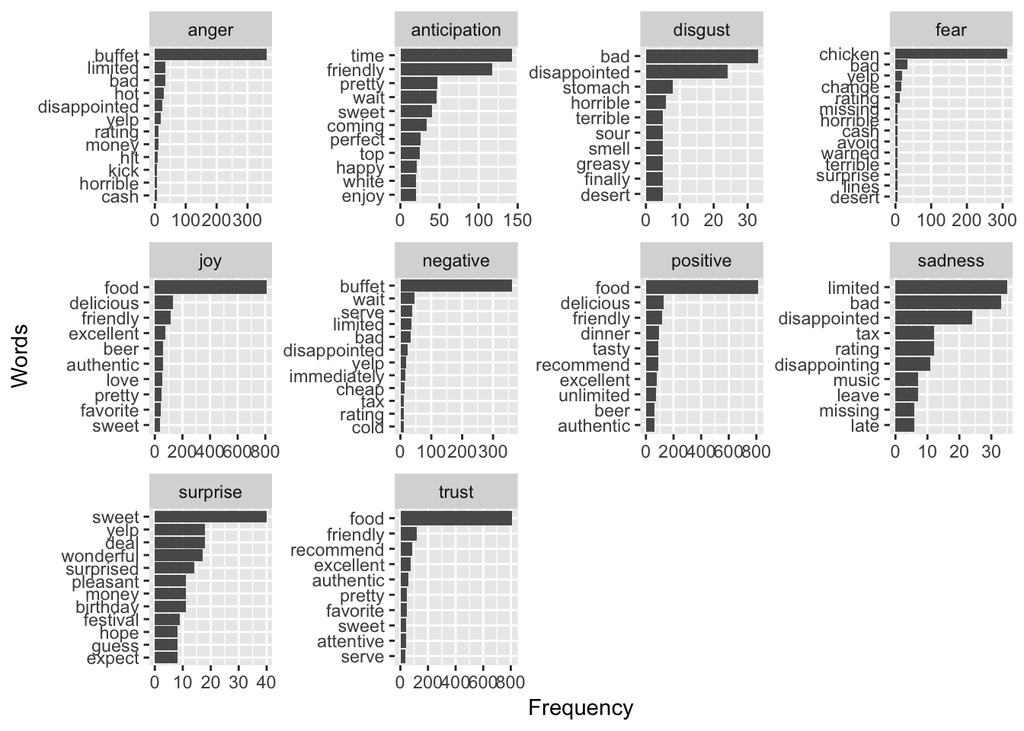

**Comments** This does put words in perspective. Lets note few words and see what was the user saying. Ex: horrible,cash, wait, stomach, smell, music, cheap, tax

Where do the review point to in terms of sentiments?

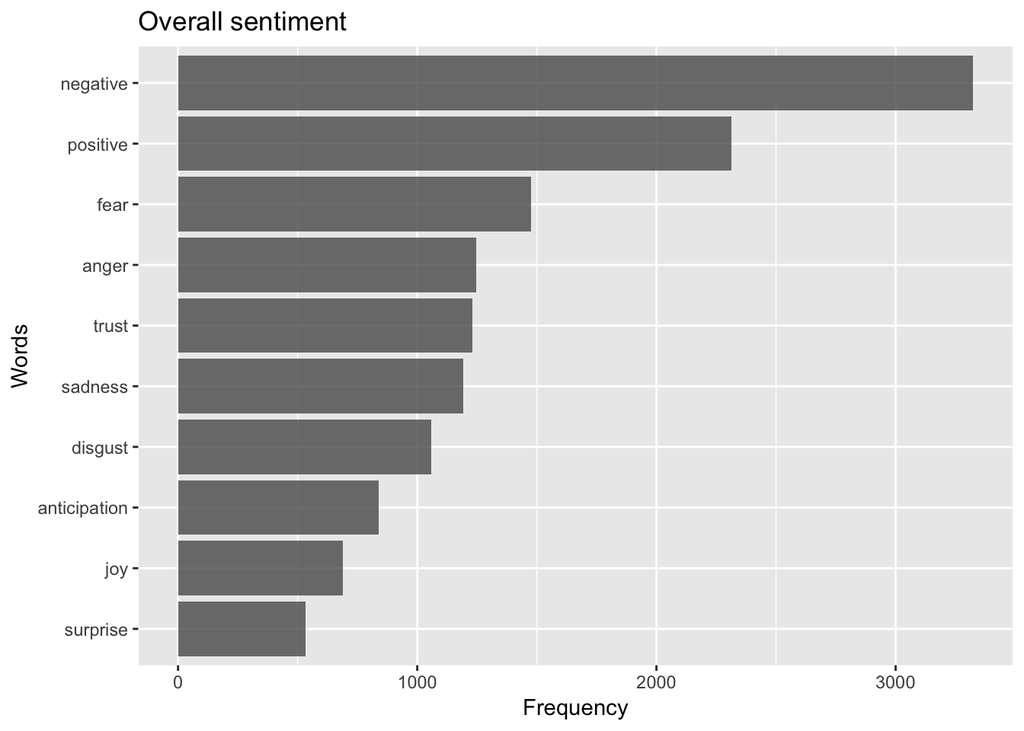

**Comments** So even though the overall ratings for this establishment is 5 the actual review sentiments are heading towards negative.

Yet to come Part 2:

Re-analyze the keywords tracked earlier for further analysis.

Sentiment analysis on entire sentence especially context.

Topic modelling on the reviews, what are various topics in the reviews.

LDA on the reviews to define various topics.